# Choosing 96 SNPs from amongst the 179 SNPs

Eric C. Anderson

Last Updated: 2021-03-04

# Introduction

In the notebook `003-process-5-plates-of-birds-at-192-fluidigm-snps.Rmd`, we processed the chips into two column format, tossed out some hard-to-score loci, ending up with 179 SNPs. In `004-combine-RAD-and-fludigm-breeders-and-run-STRUCTURE.Rmd` we retrieved the genotypes of the 175 RAD-genotyped individuals and combined them with the 393 Fluidigm-typed individuals and ran all of these 568 breeding birds through *structure* with the 179 SNPs.

From those results, it looked like there was very little variation in the *structure* output across multiple runs for the model with $K=5$, and the clusters found there reflected geography, consistently.

Now it is time to whittle those 179 loci down to a panel of 96 that we will be using to genotype the wintering birds. The way we will do this is by using the SNP allele frequencies estimated in the $K=5$ run (we use the first $K=5$ run, but they all came out the same, so it should make no difference) to guide us. I have committed with the repository the output file from that run that includes the allele frequencies at the different loci. That file is at `./stored_results/004/StructOuput_genos_slg_pipe.txt_dat001_k005_Rep001.txt_f`.

We rank each locus in terms of its utility for accurately assigning individuals from each of the 5 different clusters using the expected value of the posterior probability that an individual came from its own cluster. Let $p_1,\ldots,p_5$ denote the *structure*-estimated frequencies of the "0" allele at a SNP in the 5 clusters, respectively. Then, under HW-equilibrium it is easy to compute the expected frequencies of the three different genotypes $\begin{aligned} P_{00,i} &= p_i^2 \\ P_{01,i} &= 2p_i(1-p_i) \\ P_{11,i} &= (1-p_i)^2 \\ \end{aligned}$ for $i \in \{1,\ldots,5\}$.

If we assumed that an individual with genotype 00 was *a-priori* equally likely to be from any of the 5 clusters, then we could define the posterior probability that an 00 genotype (at a single locus) came from cluster $j$ as $Q_{00,j} = P_{00,j}/\sum_{i=1}^5 P_{00,i}$. The same goes for the heterozygote genotype (01) and the other homozygote (11). So we have: $\begin{aligned} Q_{00,j} &= \frac{P_{00,j}}{\sum_{i=1}^5 P_{00,i}} \\ Q_{01,j} &= \frac{P_{01,j}}{\sum_{i=1}^5 P_{01,i}} \\ Q_{11,j} &= \frac{P_{11,j}}{\sum_{i=1}^5 P_{11,i}}\\ \end{aligned}$ for $j \in \{1,\ldots,5\}$.

Thus, for an individual that is actually from cluster $j$ the expected posterior probability that it is from cluster $j$ based on data from this one locus is: $E_j = P_{00,j}Q_{00,j} + P_{01,j}Q_{01,j} + P_{11,j}Q_{11,j}.$ In the sequel, we use $E_j^{(\ell)}$ to refer to the $E_j$ value for locus $\ell$.

So, our approach for selecting loci here is going to be:

1. compute $E^{(\ell)}_j$ for each cluster $j$ and each locus $\ell$
2. for each cluster $j$, rank the loci in descending order of $E^{(\ell)}_j$
3. then cycle over the 5 clusters, and, each time, include in the "retained loci" list the highest-ranked locus for that cluster that has not yet been put on the "retained list". Do this until there are 96 SNPs on the "retained list."

# Functions

In order to do this easily, we write a function that takes a vector of allele frequencies from biallelic loci in $K$ different clusters/populations, and returns a vector of $E_j$ values.

```r
library(tidyverse)
source("R/Ej_from_freqs.R")
dir.create("outputs/005", showWarnings = FALSE, recursive = TRUE)
```

# Doing the selection

## Reading in the allele frequencies

We need to parse the *structure* output file. This can be done with R, but it is way easier with `awk`.

First We put them into an easily readable form in a temp file called `xxx_tmp_freqs.txt`.

```bash
rm -f xxx_tmp_freqs.txt
awk '
  /^Estimated Allele Frequencies in each cluster/ {go = 1}
  /^Locus/ && go==1 {locus = $4; n = 0; next}
  go==1 {++n}
  n==3 && go==1 {printf("%s", locus); for(i=3;i<=NF;i++) printf("\t%s", $i); printf("\n")}
  ' stored_results/004/StructOuput_genos_slg_pipe.txt_dat001_k005_Rep001.txt_f > outputs/005/tmp_struct_freqs.txt
```

Then we read those into a data frame and put some names on the columns

```r
sfreqs <- read_delim("outputs/005/tmp_struct_freqs.txt", delim = "\t", col_names = FALSE)
names(sfreqs) <- c("struct_name", paste("clust_", 1:5, sep = ""))
```

## Getting the full locus names

There is one silly wrinkle here: *structure* truncates the locus names. Jeez!! Fortunately, we have them in the slg_pipe output. The respository has a copy of them in a text file at `inputs/004/slg-pipe-locus-order.rds`. We read that in and then fill out the locus names.

Anyhow, it is just a quick slap of the locus names on there.

```r
fullloc <- read_rds(file = "inputs/004/slg-pipe-locus-order.rds")
sfreqs2 <- sfreqs %>%
  mutate(locus = fullloc) %>%
  select(locus, clust_1:clust_5)

# here is what that looks like:
sfreqs2
```

| locus | clust_1 | clust_2 | clust_3 | clust_4 | clust_5 |
| --- | --- | --- | --- | --- | --- |
| ada_brew_1 | 0.605 | 0.943 | 0.811 | 0.762 | 0.361 |
| ada_brew_17 | 0.820 | 0.735 | 0.856 | 0.784 | 0.805 |
| ada_ext_11 | 0.467 | 0.374 | 0.702 | 0.359 | 0.217 |
| ada_ext_4 | 0.968 | 0.980 | 0.573 | 0.963 | 0.996 |
| ada_Kern_3 | 0.961 | 0.834 | 0.931 | 0.933 | 0.997 |
| ada_tra_6 | 0.962 | 0.705 | 0.965 | 0.776 | 0.452 |
| brew_ext_10 | 0.831 | 0.633 | 0.995 | 0.767 | 0.941 |
| brew_ext_3 | 0.834 | 0.908 | 0.602 | 0.838 | 0.707 |
| brew_Kern_3 | 0.261 | 0.509 | 0.511 | 0.440 | 0.359 |
| brew_NS_7 | 0.705 | 0.714 | 0.400 | 0.656 | 0.568 |

[output cut: 169 more lines]

## Choosing the top 96 loci

This is a matter of sorting by rank and cluster and then taking unduplicated ones until we have 96

```r
stidy <- sfreqs2 %>%
  tidyr::gather(data = ., key = "cluster", value = "freq", clust_1:clust_5)

picks <- stidy %>%
  group_by(locus) %>%
  mutate(Ej = Ej_from_freqs(freq)) %>%
  group_by(cluster) %>%
  mutate(rank = rank(desc(Ej))) %>%
  ungroup() %>%
  arrange(rank) %>%
  mutate(first_occurrence = !duplicated(locus),
         cml = cumsum(first_occurrence),
         include = (first_occurrence == TRUE) & (cml <= 96))
```

If we want to have a look at the freqs we can page through this:

```r
left_join(picks, sfreqs2) %>%
  select(-first_occurrence, -freq)
```

| locus | cluster | Ej | rank | cml | include | clust_1 | clust_2 | clust_3 | clust_4 | clust_5 |
| --- | --- | --- | --- | --- | --- | --- | --- | --- | --- | --- |
| ada_WM_6 | clust_1 | 0.7491235 | 1 | 1 | TRUE | 0.280 | 0.943 | 0.993 | 0.925 | 0.990 |
| brew_tra_1 | clust_2 | 0.4774170 | 1 | 2 | TRUE | 0.748 | 0.255 | 0.889 | 0.585 | 0.946 |
| ada_ext_1 | clust_3 | 0.7420034 | 1 | 3 | TRUE | 0.991 | 0.941 | 0.319 | 0.946 | 0.998 |
| brew_tra_14 | clust_4 | 0.2735743 | 1 | 4 | TRUE | 0.978 | 0.523 | 0.897 | 0.621 | 0.966 |
| ext_tra_5 | clust_5 | 0.7856068 | 1 | 5 | TRUE | 0.905 | 0.925 | 0.905 | 0.713 | 0.071 |
| ext_pure_Kern_5 | clust_1 | 0.6740522 | 2 | 6 | TRUE | 0.053 | 0.706 | 0.906 | 0.722 | 0.632 |
| brew_tra_9 | clust_2 | 0.3717976 | 2 | 7 | TRUE | 0.190 | 0.646 | 0.304 | 0.414 | 0.014 |
| brew_ext_6 | clust_3 | 0.6146368 | 2 | 8 | TRUE | 0.998 | 0.991 | 0.583 | 0.970 | 0.998 |
| ada_ext_10 | clust_4 | 0.2611643 | 2 | 9 | TRUE | 0.654 | 0.419 | 0.685 | 0.345 | 0.622 |
| brew_tra_3 | clust_5 | 0.7390769 | 2 | 10 | TRUE | 0.985 | 0.975 | 0.947 | 0.870 | 0.230 |

[output cut: 885 more lines]

Let us write out the top 96 loci:

```r
top96 <- picks %>%
  filter(include == TRUE)

# and write them to the intermediates directory
write_csv(top96, file = "outputs/005/top96_loci.csv")
```

# Looking at our choices

Just going to make a quick histogram of the $E_j$ values that got specifically chosen for the different clusters.

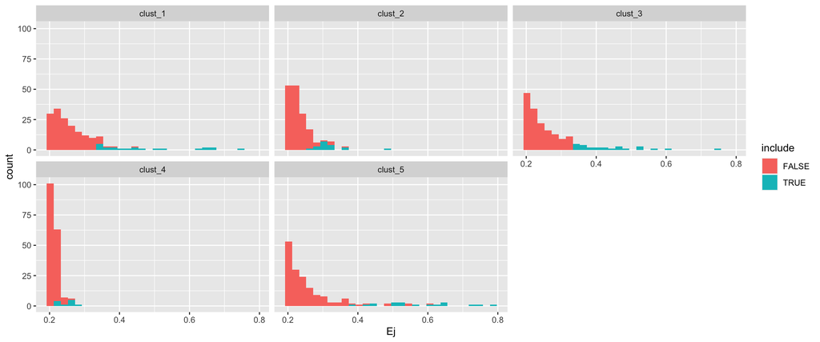

```r
ggplot(picks, aes(x = Ej, fill = include)) +
  geom_histogram(bins = 30) +
  facet_wrap(~ cluster, ncol = 3)
```

But, of course, if we want to see all the included loci we have to do something a little different

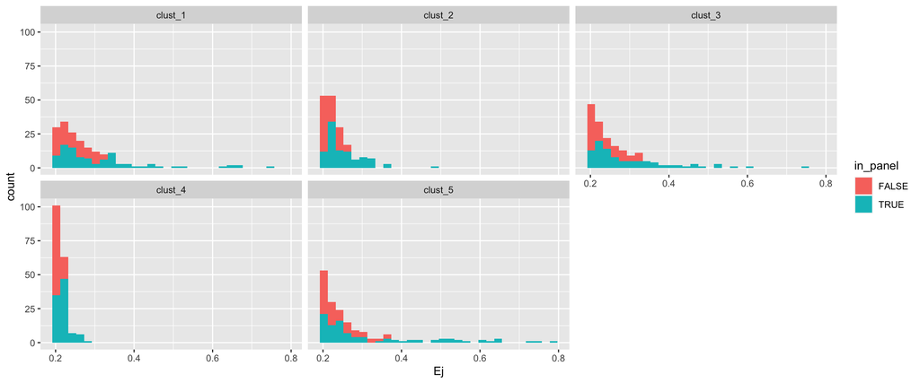

```r
tmp <- picks %>%
  mutate(in_panel = locus %in% top96$locus)

ggplot(tmp, aes(x = Ej, fill = in_panel)) +
  geom_histogram(bins = 30) +
  facet_wrap(~ cluster, ncol = 3)
```

# Running Time

Running the code and rendering this notebook required approximately this much time on a Mac laptop of middling speed, listed in `HH:MM:SS`.

```r
td <- Sys.time() - start_time
tdf <- hms::as_hms(ceiling(hms::as_hms(td)))
dir.create("stored_run_times", showWarnings = FALSE, recursive = TRUE)
write_rds(tdf, "stored_run_times/005.rds")
tdf
```

```
## 00:00:05
```